# Sculpting Data for Fun and Profit

Rent & housing price is a fundamental part of the economics of society. It is a major driver of both urbanization, de-urbanization, and internal social shifts in habitation within cities. Further, the housing market, its structure, and its behavior is the [single most important driver of the business cycle](https://ideas.repec.org/p/nbr/nberwo/13428.html), meaning that, fundamentally, the negotiations between landlords & tenants, sellers & buyers drives both the speed, duration, and the depth of recession and serves as a clear and substantial driver of income inequality in cities. At this point, you’ve probably heard of [“gentrification”](https://www.bristolpost.co.uk/news/bristol-news/gentrification-bristol-what-it-happening-3030745), and that’s driven by house prices, too. So, let’s look at house prices since 1996 in the West of England Combined Authority.

And, we’ll use the following three packages:

```r
library(tidyverse) # for tidy tools and reshaping methods
library(sf) # for working with spatial data
library(ggplot2) # for plotting
```

## The data

I provide the dataset, `weca.gpkg`, a [“geopackage”](https://www.geopackage.org/) containing the median home sale price in each LSOA in each quarter (i.e. every March, June, September, & December) starting in December of 1995 across the West of England Combined Authority. Just like most spatial data, you can read it using `sf::st_read`.

You may need to change this code in order for it to run successfully on your own computer. Notably, make sure you know where your data is, and where your code is running. Make sure to set your working directory, and put the data in a place where you can get to it from that working directory.

| lsoa_name | price_dec_1995 | price_mar_1996 | price_jun_1996 |
| --- | --- | --- | --- |
| Bath and North East Somerset 007A | 49000 | 54000 | 85500 |
| Bath and North East Somerset 007B | 68250 | 68950 | 67000 |
| Bath and North East Somerset 007C | 72500 | 73750 | 66500 |
| Bath and North East Somerset 010E | 111250 | 110000 | 103500 |
| Bath and North East Somerset 010B | 70000 | 89500 | 89500 |
| Bath and North East Somerset 010A | 62500 | 60500 | 64000 |

Viewing the columns of this dataframe yourself, you’ll see that the identifiers for each lsoa are `lsoa_code` and `lsoa_name`. The local authority for those LSOAs are recorded in `la_code` and `la_name`. Then, all of the rest of the columns are in the form `price_<month>_<year>`, and records the median price (in £) of all houses sold in that LSOA in that time period. Above, I’ve shown a cleaned-up view using just the `lsoa_name` and a few price columns, to give you a sense of what the data looks like.

Strictly speaking, the `<month>` refers to a whole [*fiscal quarter*](https://investinganswers.com/dictionary/q/quarter-q1-q2-q3-q4#:~:text=A%20fiscal%20quarter%20is%20a,the%20payment%20of%20stock%20dividends.), and uses the month name because that is much more informative than simply the quarter number.

## 1. Taking a first look at the data

According to Wickham (2014), there are five common problems with “messy” datasets that generally can be resolved by “tidying” the data.

If you consult [Section 3 of the Wickham (2014) paper on tidy data](http://www.jstatsoft.org/v59/i10/paper), you’ll find the common problems and discussion. These problems are: “column headers are values, not variable names” ; “multiple variables are stored in one column”; “variables stored in both rows and columns”; “multiple types are in one table”; “one type in multiple tables.”

### 1.1

The following dataset of temperatures from the Filton weather station has a different tidiness problem. Which problem is it, and how can you tell?

```r
library(readr)
temps = read_csv("../data/bristol_yearly_temps.csv")
temps
```

| year | stat | degrees_celsius |
| --- | --- | --- |
| 2016 | maximum | 18.7 |
| 2016 | median | 10.6 |
| 2016 | minimum | 6.1 |
| 2017 | maximum | 18.4 |
| 2017 | median | 12.4 |
| 2017 | minimum | 5.5 |
| 2018 | maximum | 21.1 |
| 2018 | median | 11.5 |
| 2018 | minimum | 4.4 |

*This temperature data is too long. It mixes information about different kinds of statistics in the* `stat` *column, and therefore contains many different kinds of temperatures in the* `degrees_celsius` *column. This is Wickham’s second problem: multiple variables are stored in a single column; the maximum, minimum, and median temperatures are all stored within the* `degrees_celsius` *column.*

### 1.2

How would you tidy the data & compute the range of temperatures for each year?

*To resolve this issue, we need to* `spread`*, or* `pivot_wider`, *the data to split the `stat` column into three variables.*

```r
temps_wide = pivot_wider(temps,
            id_cols=year, # this uniquely identifies each row
            names_from=stat, # this contains the "names" of our variables
            values_from=degrees_celsius # this contains the values of our variables
            )
temps_wide %>% mutate(range = maximum - minimum)
```

| year | maximum | median | minimum | range |
| --- | --- | --- | --- | --- |
| 2013 | 20.9 | 10.55 | 4.4 | 16.5 |
| 2014 | 20.0 | 12.80 | 6.5 | 13.5 |
| 2015 | 17.3 | 12.05 | 5.3 | 12.0 |
| 2016 | 18.7 | 10.60 | 6.1 | 12.6 |
| 2017 | 18.4 | 12.40 | 5.5 | 12.9 |
| 2018 | 21.1 | 11.50 | 4.4 | 16.7 |

*An alternative approach to compute the temperature range might filter the* `temps` *data. This is more complicated, even though it provides the right result. This is because the actual “pivot” occurs manually: you select the maximum and minimum values individually using the* `filter` *and* `select` *verbs. This only works because you know the columns that will be needed for the range, and that number of columns is relatively small. If the spread were more complicated, or involved more variables, this would entail significant copying & pasting.*

```r
maxes = temps %>% filter(stat == 'maximum') %>% # get the maximum column
                     select(-stat) %>% # drop the stat column, just keep year & value
                     rename(maximum = degrees_celsius) # rename the degrees to maximum
mins = temps %>% filter(stat=='minimum') %>%
                 select(-stat) %>% # drop the stat column, as before
                 rename(minimum = degrees_celsius) # rename the degrees to minimum
join = merge(maxes, mins, by='year') # join the minima and maxima by years
join %>% mutate(range = maximum - minimum) # compute the range
```

|  | year | maximum | minimum | range |
| --- | --- | --- | --- | --- |
| 114 | 2013 | 20.9 | 4.4 | 16.5 |
| 115 | 2014 | 20.0 | 6.5 | 13.5 |
| 116 | 2015 | 17.3 | 5.3 | 12.0 |
| 117 | 2016 | 18.7 | 6.1 | 12.6 |
| 118 | 2017 | 18.4 | 5.5 | 12.9 |
| 119 | 2018 | 21.1 | 4.4 | 16.7 |

### 1.3

The `weca` data has one of these issues. Which one does it have, and how can you tell?

*The* `weca` *data is too wide. It mixes information about the quarter/year in with the information about price. This means that the data has Wickham’s first problem: column headers are values, not variable names. In theory, lsoa, la, price, quarter, and year are distinct variables that each encode a distinct bit of information about the observation. Further, this means that the “tidy” version of this data contains a single row for the price of a single LSOA in a single quarter in a single year. The data needs to be “melted” to become tidy, which will be completed in the next step.*

## 2. Tidying Data

## 2.1

It will be helpful to have tidy data for some analyses in the remainder of the exercise. Use a pivot to transform the data to make each row measure the price of an LSOA in a specific month & year

```r
wecatidy = pivot_longer(weca, price_dec_1995:price_dec_2018, names_to=c(NA, 'quarter', 'year'), names_sep='_', values_to='price')
```

| la_code | la_name | lsoa_code | lsoa_name | lsoa11cd | geom | quarter | year | price |
| --- | --- | --- | --- | --- | --- | --- | --- | --- |
| E06000022 | Bath and North East Somerset | E01014370 | Bath and North East Somerset 007A | E01014370 | MULTIPOLYGON (((-2.357691 5… | dec | 1995 | 49000 |
| E06000022 | Bath and North East Somerset | E01014370 | Bath and North East Somerset 007A | E01014370 | MULTIPOLYGON (((-2.357691 5… | mar | 1996 | 54000 |
| E06000022 | Bath and North East Somerset | E01014370 | Bath and North East Somerset 007A | E01014370 | MULTIPOLYGON (((-2.357691 5… | jun | 1996 | 85500 |
| E06000022 | Bath and North East Somerset | E01014370 | Bath and North East Somerset 007A | E01014370 | MULTIPOLYGON (((-2.357691 5… | sep | 1996 | 122000 |
| E06000022 | Bath and North East Somerset | E01014370 | Bath and North East Somerset 007A | E01014370 | MULTIPOLYGON (((-2.357691 5… | dec | 1996 | 129000 |
| E06000022 | Bath and North East Somerset | E01014370 | Bath and North East Somerset 007A | E01014370 | MULTIPOLYGON (((-2.357691 5… | mar | 1997 | 129000 |

### 2.2

Using your new tidy data, use `ggplot2` to make a boxplot where the horizontal axis is years, the vertical axis is price, and boxes are colored by local authority.

The `ggplot2` library has some helpful guidance [online](https://ggplot2.tidyverse.org/reference/geom_boxplot.html). Pay critical attention to what the [options are](http://www.sthda.com/english/wiki/ggplot2-box-plot-quick-start-guide-r-software-and-data-visualization#change-box-plot-colors-by-groups), and what the question asks you to do.

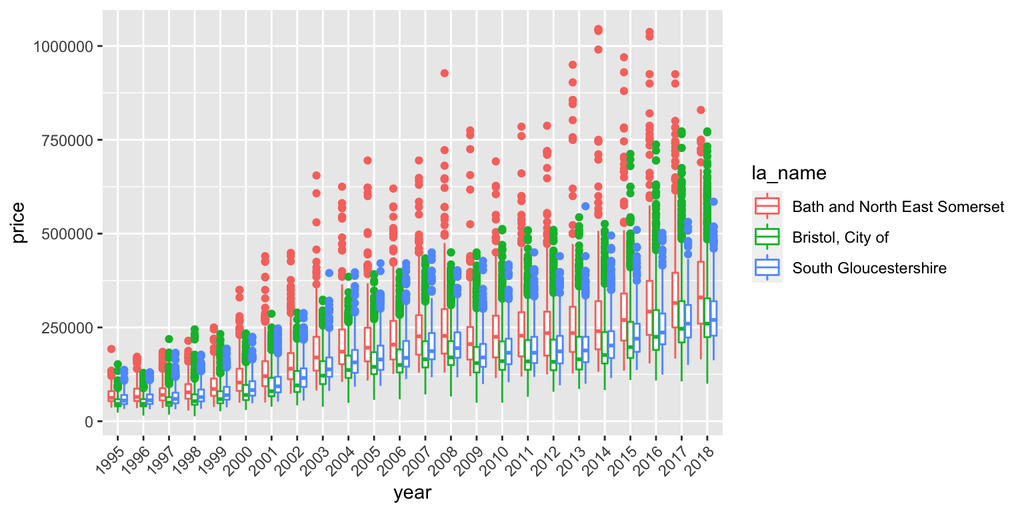

```r
ggplot(wecatidy, aes(x=year, y=price, color=la_name)) + geom_boxplot() + theme(axis.text.x = element_text(angle=45, vjust=1, hjust=1))
```

### 2.3

Using tidy verbs such as `group_by`, `select`, `mutate`, and `merge`, can you:

- compute the average price for each year? *This can be done using a group by + summarize*

```r
wecatidy %>% group_by(year) %>% summarize(mean_price = mean(price))
```

| year | mean_price |
| --- | --- |
| 1995 | NA |
| 1996 | NA |
| 1997 | NA |
| 1998 | NA |
| 1999 | NA |
| 2000 | NA |

- compute the average price in each local authority each year? *This can be done using a group by + summarize. Note that there are now **two levels** which we need to capture: the year and the local authority. Summarize operates on each group in sequence, from right to left. Thus, if we `groupby(year, la_name)`, then the summary is built first for `la_name`, then `year`, if requested:*

```r
wecatidy %>% group_by(year, la_name) %>%
  summarize(mean_price = mean(price, na.rm=T))
```

| year | la_name | mean_price |
| --- | --- | --- |
| 1995 | Bath and North East Somerset | 70375.12 |
| 1995 | Bristol, City of | 51259.92 |
| 1995 | South Gloucestershire | 60340.01 |
| 1996 | Bath and North East Somerset | 72169.71 |
| 1996 | Bristol, City of | 51352.70 |
| 1996 | South Gloucestershire | 61347.14 |

- Compute the median price for each LSOA since 2008? *this is slightly more complex, requiring a filter operation, and the recognition that you can groupby(lsoa_code), just like any other group.*

```r
wecatidy %>% filter(year >= 2008) %>%
  group_by(lsoa_code) %>% summarize(price = median(price))
```

| lsoa_code | price |
| --- | --- |
| E01014370 | 254375.0 |
| E01014371 | 251662.5 |
| E01014372 | 280000.0 |
| E01014373 | 224250.0 |
| E01014374 | 317500.0 |
| E01014375 | 399499.0 |

- **Challenge: make a map of the *percentage change* in prices for each LSOA since 2008?** *This requires the hint information, plus everything we’ve done before.*

  The `first` and `last` functions get the values of the first group and the last group in a `group_by`. And, percent change in variable $x$ measured at time $t$ is computed by $\frac{x_{t+1} - x_t}{x_t}$.

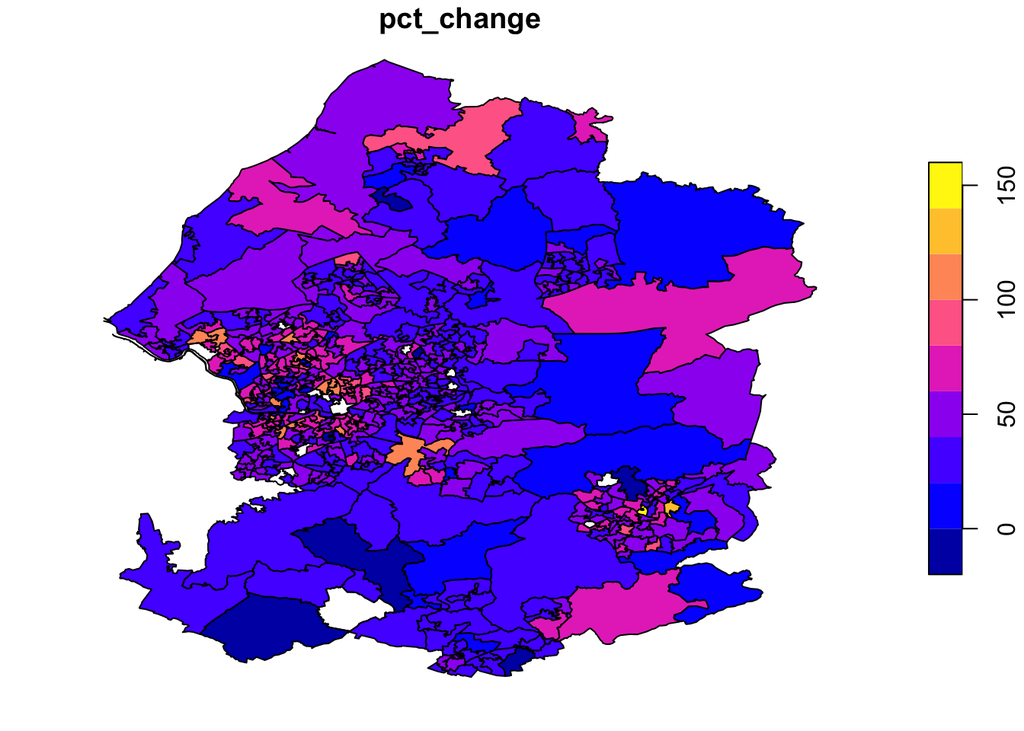

```r
price_changes = wecatidy %>% filter(year >= 2008) %>%
                             group_by(lsoa_code, year) %>%
                             summarize(price = mean(price)) %>%
                             arrange(year) %>%
                             summarize(pct_change = (last(price) - first(price))/first(price)*100)
price_changes = merge(weca[c('lsoa_code', 'geom')], price_changes, by='lsoa_code')
plot(price_changes['pct_change'])
```

```r
price_changes
```

| lsoa_code | pct_change | geometry |
| --- | --- | --- |
| E01014370 | 30.858066 | MULTIPOLYGON (((-2.357691 5… |
| E01014371 | 76.995664 | MULTIPOLYGON (((-2.351819 5… |
| E01014372 | 32.456140 | MULTIPOLYGON (((-2.356748 5… |
| E01014373 | 46.801531 | MULTIPOLYGON (((-2.320094 5… |
| E01014374 | 28.225176 | MULTIPOLYGON (((-2.307303 5… |
| E01014375 | 4.899572 | MULTIPOLYGON (((-2.342037 5… |